# Model_description

2024-02-02

Ok so picking this back up now that I have a sense of how to integrate effects across different levels of the heirarchy.

Let start by describing the model. Kai has data at two hierarchical levels: the plot level and the level of the individual coral colony.

```r
library(tidyverse)
```

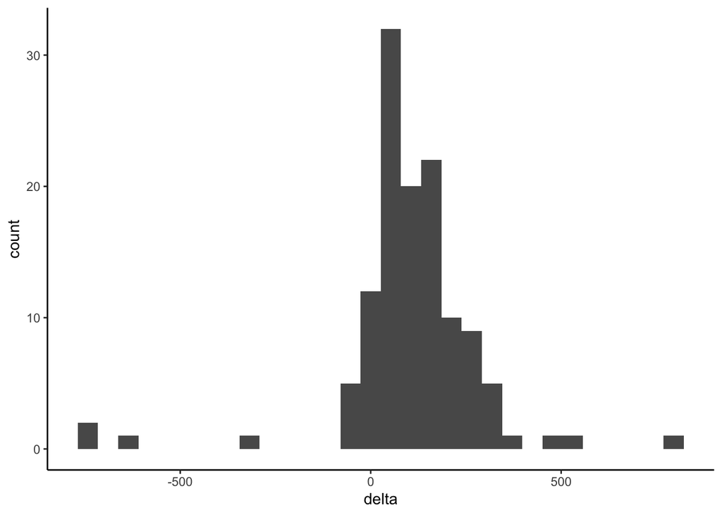

```r
df <- read.csv("data/bart_bayesian.csv")

df %>%
  mutate(delta = august_2019_area - july_2022_area) %>%
  ggplot(aes(x = delta))+
  geom_histogram()+
  theme_classic()
```

```r
df %>%
  group_by(plot, treatment) %>%
  summarize(total_live_2019 = sum(august_2019_area),
            total_live_2022 = sum(july_2022_area)) %>%
  pivot_longer(cols = total_live_2019:total_live_2022)
```

```
## # A tibble: 4 × 4
## # Groups:   plot [2]
##    plot treatment name             value
##   <int> <chr>     <chr>            <dbl>
## 1    11 Removal   total_live_2019 11720.
## 2    11 Removal   total_live_2022  7385.
## 3    12 Retention total_live_2019 11351.
## 4    12 Retention total_live_2022  2759.
```

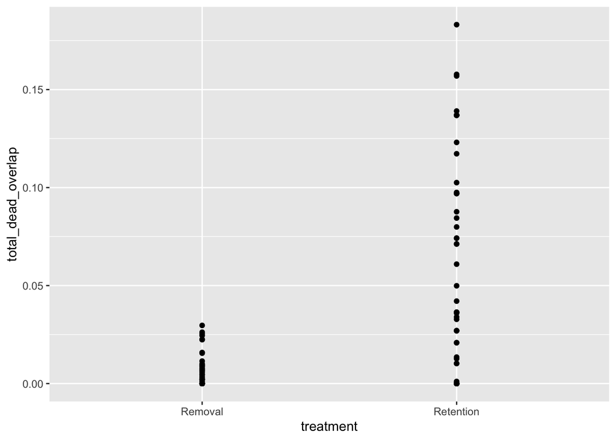

```r
df %>%
  ggplot(aes(x = treatment, y = total_dead_overlap))+
  geom_point()
```

So the variable initial_live is just the sum of total LCC in august 2019. And total_dead_overlap is a continuous variable similar to the effect of treatment (e.g. there isn’t much dead coral because it was removed).

Ok, so we want to model the size of coral $i$, in year, $y$, (e.g. $C_{i,y}$) as a function of coral size in the last time step ($C_{i,y-1}$), the amount of growing space available to the coral, $S$. $S = 1 - (D+L)$ where $D$ is the area occupied by dead coral and $L$ is the amount of space occupied by live corals within a certain buffered distance, $\omega$, that is externally specified.

$$\begin{aligned}
C_{i,y} &\sim Normal(\mu_{i,y}, \sigma^2) &&
\text{Likelihood function}\\
predC_{i,y} &= predC_{i, y-1} + r_{p,i} &&
\text{Autoregressive process}\\
\mu_{i,y} &\sim Normal(predC_{i,y}, \sigma_{mu_c}) &&
\text{Hyperprior on plot level, LCC}\\
r_{p,i} &= r_p + \gamma_p + \beta_S S_{p,i} && \text{Linear
regression on coral growth rate, r}\\
r_p &= \alpha_{0,p} + \beta_{T = removal} T && \text{Higher
order effects of treatment on plot level intercept}\\
\end{aligned}$$

$$
$$\begin{aligned}
C_{i,y} &\sim Normal(\mu_{i,y}, \sigma^2) &&
\text{Likelihood function}\\
predC_{i,y} &= predC_{i, y-1} + r_{p,i} &&
\text{Autoregressive process}\\
\mu_{i,y} &\sim Normal(predC_{i,y}, \sigma_{mu_c}) &&
\text{Hyperprior on plot level, LCC}\\
r_{p,i} &= \alpha_{0} + \gamma_p + \beta_{T = removal} T + \beta_S
S_{p,i} + \beta_{int} S_{p,i} T && \text{Linear regression on
coral growth rate, r}\\
\end{aligned}$$

Ok, so going to change around notation here and use the MARSS style notation for a univariate state-space model. Let’s let $x_t$ represent the “true state” of nature. In our case this represents the areal size of each individual coral. $y_t$ represents our observations of this true state. $w_t$ represents error in the process model and $v_t$ represents error (e.g. variance) in our observations. We will assume a simple autoregressive (ar1) function. Furthermore, we will assume that our covariates influence only the process model, not the observation model.

$$\begin{aligned}
\text{Model}\\
\\
x_{t,p} &= \phi x_{t-1} + r_{t,p} + w_t && \text{Process
model}\\
r_{t,p} &= \alpha_{0} + \gamma_p + \beta_{T = removal} T + \beta_S
S_{p,t} + \beta_{X} S_{p,t} T && \text{Covariate component of
process model}\\
y_{t,p} &= x_{t,p} + v_{t} && \text{Observation model}\\
\end{aligned}$$
We now have to translate this model into Bayesian terms. Here I’ll let $\hat{y}$ represent the expected value of $y$, and $\hat{x}$ the expected value of x.

$$
$$\begin{aligned}
\text{Model}\\
\\
\hat{x}_{t,p} &= \phi x_{t-1} + r_{t,p} && \text{Process
model}\\
r_{t,p} &= \alpha_{0} + \gamma_p + \beta_{T = removal} T + \beta_S
S_{p,t} + \beta_{X} S_{p,t} T && \text{Covariate component of
process model}\\
\\
\text{Likelihood}\\
\\
x_{t,p} &\sim Normal(\hat{x}_{t,p}, w_t) && \text{Latent
state with ar1 autocorrelated errors} \\
y_{t,p} &\sim Normal(x_{t,p}, v_t) && \text{Observation
model with v_t error}\\
\\
\text{Priors}\\
\\
\beta_X |\beta_S|\beta_T &\sim Normal(0, 10) && \text{Priors
on covariate coefficients}\\
\alpha_0 &\sim Normal(0, 10) && \text{Prior on global
intercepts (Removal vs. Retention)}\\
\gamma_p &\sim Normal(0, \sigma^2) && \text{Prior on
plot-level deviations from the global intercepts}\\
\sigma &\sim Exp(1) && \text{Prior on standard deviation of
plot level effects}\\
w_t &\sim Exp(1) && \text{Prior on process variance}\\
v_t &\sim Exp(1) && \text{Prior on observation variance}\\
\end{aligned}$$

```r
sink("round1.stan")
cat("
    data {

    //Index variables
    int n_plot; // Number of plots
    int n; // length of the data frame

    //Response variable
    real<lower = 0> y[n]; // Observations of coral size of each individual coral

    // Predictor variables
    real<lower=0, upper=1> S[n];  // 1-overlap where the overlap includes both live and dead coral. An index of now much free space an individual coral has to grow into.
    int T[n]; // treatment (either removal (T =1) or retention (T=0))
    int plot[n];

    }

    parameters {

    real alpha_0; // Reference level of the treatment effects (e.g. the effect of retention, when T=0)
    real beta_S; // Slope effect of space availability on individual coral growth. Does not vary across plots or treatments.
    real beta_T;
    real beta_X;
    real<lower=0> w;
    real<lower=0> v;
    real<lower=0> sigma;
    vector[n_plot] gamma;
    real x0;
    }

    transformed parameters{
    real r[n];
    real x_hat[n];

    for(i in 1:n){
        r[i] = alpha_0 + gamma[plot[i]] + beta_T*T[i] + beta_S*S[i] + beta_X*S[i]*T[i];
    }

    x_hat[1] = x0;

    for(i in 2:n){
    x_hat[i] = x_hat[i-1] + r[i];
    }


    }

    model {

    real x[n];

    //priors

    alpha_0 ~ normal(0, 10);
    beta_T ~ normal(0, 10);
    beta_S ~ normal(0, 10);
    beta_X ~ normal(0, 10);
    x0 ~ normal(0, 10);

    for(p in 1:n_plot){
      gamma[p] ~ normal(0, sigma);
    }

    w ~ exponential(1);
    v ~ exponential(1);

    // likelihood

    x ~ normal(x_hat, v);
    y ~ normal(x, w);

    }",fill = TRUE)
```

```
##
##     data {
##
##     //Index variables
##     int n_plot; // Number of plots
##     int n; // length of the data frame
##
##     //Response variable
##     real<lower = 0> y[n]; // Observations of coral size of each individual coral
##
##     // Predictor variables
##     real<lower=0, upper=1> S[n];  // 1-overlap where the overlap includes both live and dead coral. An index of now much free space an individual coral has to grow into.
##     int T[n]; // treatment (either removal (T =1) or retention (T=0))
##     int plot[n];
##
##     }
##
##     parameters {
##
##     real alpha_0; // Reference level of the treatment effects (e.g. the effect of retention, when T=0)
##     real beta_S; // Slope effect of space availability on individual coral growth. Does not vary across plots or treatments.
##     real beta_T;
##     real beta_X;
##     real<lower=0> w;
##     real<lower=0> v;
##     real<lower=0> sigma;
##     vector[n_plot] gamma;
##     real x0;
##     }
##
##     transformed parameters{
##     real r[n];
##     real x_hat[n];
##
##     for(i in 1:n){
##         r[i] = alpha_0 + gamma[plot[i]] + beta_T*T[i] + beta_S*S[i] + beta_X*S[i]*T[i];
##     }
##
##     x_hat[1] = x0;
##
```

[output cut: 17 more lines]

```
##     x0 ~ normal(0, 10);
##
##     for(p in 1:n_plot){
##       gamma[p] ~ normal(0, sigma);
##     }
##
##     w ~ exponential(1);
##     v ~ exponential(1);
##
##     // likelihood
##
##     x ~ normal(x_hat, v);
##     y ~ normal(x, w);
##
##     }
```

```r
sink()



mod <- rstan::stan_model('round1.stan')
```

```r
library(tidyverse)
df <- read.csv("data/bart_bayesian.csv") %>%
  pivot_longer(cols = c(august_2019_area:july_2022_area)) %>%
  rename(time = name) %>%
  mutate(year = ifelse(time == "august_2019_area", 1, 2))


stan_data = list("n"= length(df$genet),
                 "n_plot" = length(unique(df$plot)),
                 "y" = df$value,
                 "S" = df$total_dead_overlap,
                 "T" = ifelse(df$treatment == "Removal", 1, 0),
                 "plot" = df$plot
) # named list


stanfit <- rstan::sampling(mod,
                           data = stan_data,
                           chains = 3,
                           thin = 1,
                           iter = 2000,
                           seed = 123123)
```

```
##
## Error in eval(expr, envir, enclos) :
##   Must use algorithm="Fixed_param" for model that has no parameters.
## [1] "In addition: Warning message:" "In sink() : no sink to remove"
```

```
## error occurred during calling the sampler; sampling not done
```